```python
# Code:     Exploratory Data Analysis using data scraped from top 100 posts of subreddit r/srilanka
# Authors:  Ayush Shrivastava and Ankit Yadav
# Date:     24-08-2023
```

# **Loading the Corpus of Titles of top 100 Reddit post from r/srilanka**

For this analysis, we gathered a Corpus of Titles from the top 100 posts on the subreddit r/srilanka. To accomplish this, we employed the Python Reddit API Wrapper (PRAW), a powerful tool for extracting content from Reddit.

```python
import pandas as pd
from matplotlib import pyplot as plt
```

```python
df =pd.read_csv("./Corpus/posts_Corpus.csv")
df2=df
df2.sample(5)
```

|  | POST_ID | POST_TITLE | POST_PERMALINK | POST_URL | POST_SCORE | POST_NUM_COMMENTS | POST_CREATED_TIMESTAMP | POST_SUBREDDIT | POST_UPVOTE_RATIO | AUTHOR_USERNAME | AUTHOR_KARMA | AUTHOR_ACCOUNT_AGE | POST_TYPE | POST_TEXT_CONTENT |
| --- | --- | --- | --- | --- | --- | --- | --- | --- | --- | --- | --- | --- | --- | --- |
| 21 | 11z6vu0 | 50 years ago Sri Lanka. 1973 | https://www.reddit.com/r/srilanka/comments/11z... | https://www.reddit.com/gallery/11z6vu0 | 511 | 70 | 1.679541e+09 | srilanka | 0.99 | ordinary-peasent | 6204.0 | 369.965565 | gallery | NaN |
| 4 | ts8y67 | Indian Foreign Minister Jaishankar visits petr... | https://www.reddit.com/r/srilanka/comments/ts8... | https://pbs.twimg.com/media/FO7Oh5fXMAMHIGl.jpg | 748 | 256 | 1.648654e+09 | srilanka | 1.00 | asdafaz | 445.0 | NaN | image | NaN |
| 85 | vz4195 | 8 years later, aged like milk | https://www.reddit.com/r/srilanka/comments/vz4... | https://i.redd.it/0wc6gknatib91.jpg | 326 | 91 | 1.657827e+09 | srilanka | 0.99 | uncharteddarkside | 15813.0 | 2188.594662 | image | NaN |
| 42 | vuxq9h | Galleface at the moment. | https://www.reddit.com/r/srilanka/comments/vux... | https://i.redd.it/0wey7bnqdia91.jpg | 414 | 8 | 1.657358e+09 | srilanka | 1.00 | Ehansaja | 1085546.0 | 3194.868609 | image | NaN |
| 52 | 10pzvf1 | In Canada, we are black ✊🏿 | https://www.reddit.com/r/srilanka/comments/10p... | https://i.redd.it/jy2htfuwfffa1.jpg | 378 | 92 | 1.675174e+09 | srilanka | 0.96 | NaN | NaN | NaN | image | NaN |

```python
df2=df2.drop(["POST_ID","POST_PERMALINK","POST_URL","POST_CREATED_TIMESTAMP","POST_SUBREDDIT","POST_TEXT_CONTENT"],axis=1)
df2.head()
```

|  | POST_TITLE | POST_SCORE | POST_NUM_COMMENTS | POST_UPVOTE_RATIO | AUTHOR_USERNAME | AUTHOR_KARMA | AUTHOR_ACCOUNT_AGE | POST_TYPE |
| --- | --- | --- | --- | --- | --- | --- | --- | --- |
| 0 | This will be a historical photo. The aftermath... | 1102 | 57 | 1.00 | Lankaner | 47202.0 | 1903.160519 | image |
| 1 | Drew Lo-fi girl for Sri Lanka | 1054 | 142 | 1.00 | Ijbfhh | 3221.0 | 2197.116259 | image |
| 2 | You guys are something else! Good luck to you! | 887 | 44 | 0.99 | ReadTheBookPal | 4516.0 | 491.666144 | image |
| 3 | This made my whole day (source: Twitter) | 813 | 17 | 1.00 | sachezz | 5382.0 | 1216.299049 | image |
| 4 | Indian Foreign Minister Jaishankar visits petr... | 748 | 256 | 1.00 | asdafaz | 445.0 | NaN | image |

# **Exploratory Data Analysis**

## **Analysis of various Post parameters**

### **Post Score Distribution**

To gain insights into the engagement and structure of Posts within the r/srilanka subreddit, we will analyze the distribution of Post scores. These visualizations can reveal trends that may provide valuable information about user interactions and content popularity.

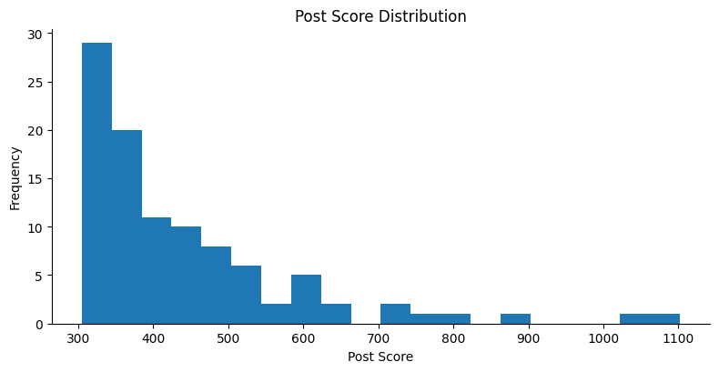

```python
def histogram(df, colname, num_bins=20, figscale=1):
  df[colname].plot(kind='hist', bins=num_bins, title=colname, figsize=(8*figscale, 4*figscale))
  plt.gca().spines[['top', 'right',]].set_visible(False)
  plt.tight_layout()
  # return autoviz.MplChart.from_current_mpl_state()

chart = histogram(df2, *['POST_SCORE'], **{})
plt.title('Post Score Distribution')
plt.xlabel('Post Score')
plt.ylabel('Frequency')
chart
```

### **Distribution of comments on Post**

To gain insights into the popularity of Posts within the r/srilanka subreddit, we will analyze the distribution of Post commnents. These visualizations can reveal trends that may provide valuable information about user interactions and content popularity.

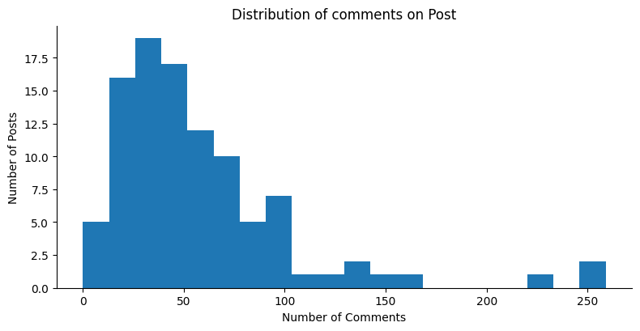

```python
chart = histogram(df2, *['POST_NUM_COMMENTS'], **{})
plt.title('Distribution of comments on Post')
plt.xlabel('Number of Comments')
plt.ylabel('Number of Posts')
chart
```

### **Relation between POST_SCORE and POST_UPVOTE_RATIO**

To gain insights into the popularity of Posts by post score and post upvote ration within the r/srilanka subreddit, we will analyze the distribution of Post scores and upvote ratio.

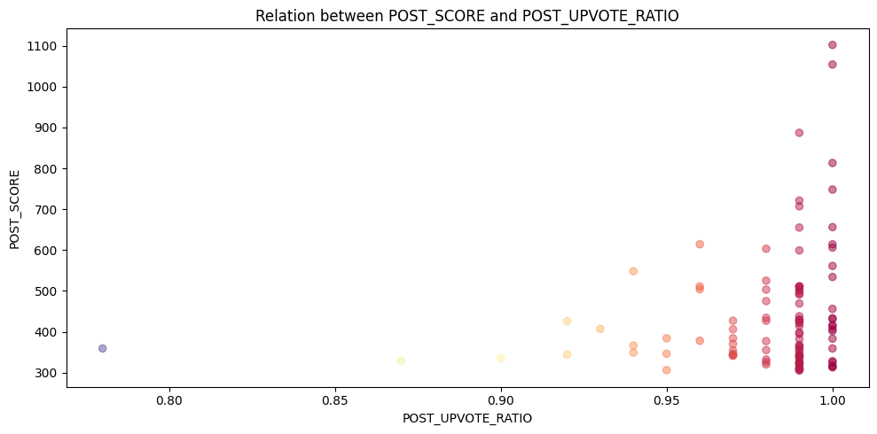

```python
# PLotting a scatter plot of comment score vs comment depth
plt.figure(figsize=(10,5) ,dpi=100,tight_layout=True)

plt.scatter(df2['POST_UPVOTE_RATIO'],df2['POST_SCORE'],alpha=0.5,c=abs(df2['POST_UPVOTE_RATIO']),cmap='Spectral_r')
plt.title('Relation between POST_SCORE and POST_UPVOTE_RATIO')
plt.xlabel('POST_UPVOTE_RATIO')
plt.ylabel('POST_SCORE')
```

### **Post Type**

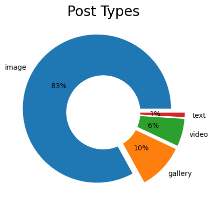

```python
df2['POST_TYPE'].value_counts().plot(kind='pie',autopct='%1.0f%%',explode=(0.1,0.1,0.1,0.1))
plt.pie([1], radius=0.5, colors='w')
plt.ylabel("")
plt.title('Post Types', fontsize=20)
```

### **Most Active Users in r/srilanka subreddit.**

This statistics can help us understand who contributes the most to discussions and potentially who holds influential positions within the subreddit.

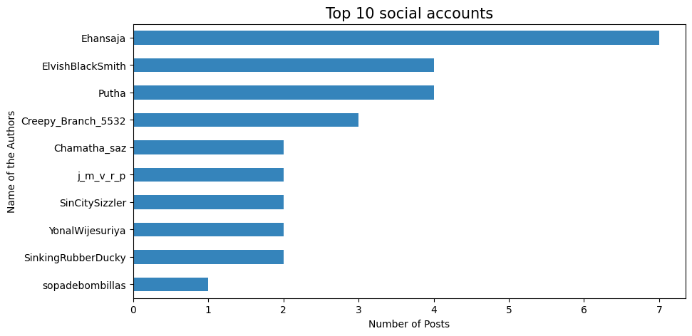

```python
plt.figure( figsize=(10, 5),dpi=100)
df2['AUTHOR_USERNAME'].value_counts(ascending=True).tail(10).plot(kind='barh',color='C0',alpha=0.9)
plt.xlabel('Number of Posts')
plt.ylabel('Name of the Authors')
plt.title('Top 10 social accounts', fontsize=15)
plt.show()
```

## **Analyzing text statistics**

Text statistics visualizations are simple but very insightful techniques.

They include:

- word frequency analysis,
- sentence length analysis,
- average word length analysis, etc.

Those really help explore the fundamental characteristics of the text data.

First, I’ll take a look at the number of characters present in each sentence. This can give us a rough idea about the Title length.

### **Analysing character count in Post titles**

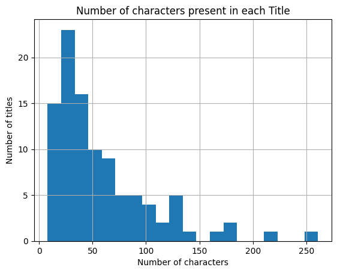

```python
df2['POST_TITLE'].str.len().hist(bins=20)
plt.title('Number of characters present in each Title')
plt.xlabel('Number of characters')
plt.ylabel('Number of titles')
```

The histogram shows that post title range from 10 to 250 characters and generally, it is between 10 to 140 characters.

Now, we will move on to data exploration at a word-level. Let’s plot the number of words appearing in each post title.

### **Analysing word count in Post titles**

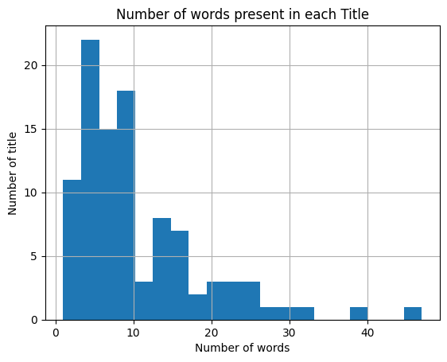

```python
df2['POST_TITLE'].str.split().map(lambda x: len(x)).hist(bins=20)
# x-axis = number of words
# y-axis = freq of post
plt.title('Number of words present in each Title')
plt.xlabel('Number of words')
plt.ylabel('Number of title')
```

It is clear that the number of words in post title ranges from 1 to 45 and mostly falls between 1 to 35 words.

```python
import numpy as np
```

Up next, let’s check the average word length in each sentence.

### **Word length Analysis**

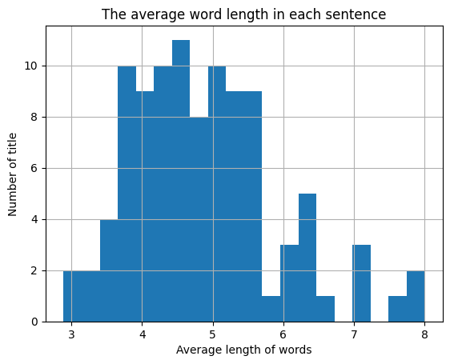

```python
#let’s check the average word length in each sentence.
df2['POST_TITLE'].str.split().apply(lambda x : [len(i) for i in x]).map(lambda x: np.mean(x)).hist(bins=20)
plt.title('The average word length in each sentence')
plt.xlabel('Average length of words')
plt.ylabel('Number of title')
```

The average word length ranges between 2 to 8 with 5 being the most common length. Does it mean that people are using really short words in Post title?Let’s find out.

Analyzing the amount and the types of stopwords can give us some good insights into the data.

To get the corpus containing stopwords you can use the nltk library. Nltk contains stopwords from many languages. Since we are only dealing with English news I will filter the English stopwords from the corpus.

### **Stopword Analysis**

```python
#Analyzing the amount and the types of stopwords can give us some good insights into the data
import nltk
from nltk.corpus import stopwords
nltk.download('stopwords')
stop=set(stopwords.words('english'))
```

```python
import matplotlib.pyplot as plt

corpus=[]
new= df2['POST_TITLE'].str.split()
```

```python
def plot_top_stopwords_barchart(text):
    stop=set(stopwords.words('english'))

    new= text.str.split()
    new=new.values.tolist()
    corpus=[word for i in new for word in i]
    from collections import defaultdict
    dic=defaultdict(int)
    for word in corpus:
        if word in stop:
            dic[word]+=1

    top=sorted(dic.items(), key=lambda x:x[1],reverse=True)[:10]
    x,y=zip(*top)
    plt.bar(x,y)
```

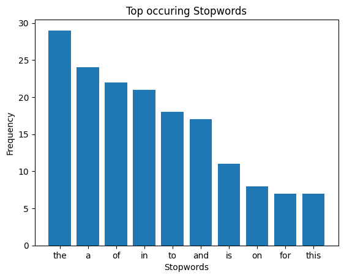

```python
plot_top_stopwords_barchart(df2['POST_TITLE'])
plt.title('Top occuring Stopwords')
plt.xlabel('Stopwords')
plt.ylabel('Frequency')
```

We can evidently see that stopwords such as "the",”a” and “OF” dominate in news headlines.

So now we know which stopwords occur frequently in our text, let’s inspect which words other than these stopwords occur frequently.

We will use the counter function from the collections library to count and store the occurrences of each word in a list of tuples. This is a very useful function when we deal with word-level analysis in natural language processing.

### **Analysing Nonstop words**

```python
# So now we know which stopwords occur frequently in our text, let’s inspect which words other than these stopwords occur frequently.
import seaborn as sns
from nltk.corpus import stopwords
from collections import  Counter

def plot_top_non_stopwords_barchart(text):
    stop=set(stopwords.words('english'))

    new= text.str.split()
    new=new.values.tolist()
    corpus=[word for i in new for word in i]
    lowercased_tokens = [token.lower() for token in corpus]
    cleaned_tokens = [token for token in lowercased_tokens if token.isalpha()]



    counter=Counter(cleaned_tokens)
    most=counter.most_common()
    x, y=[], []
    for word,count in most[:50]:
        if (word not in stop):
            x.append(word)
            y.append(count)

    sns.barplot(x=y,y=x)
```

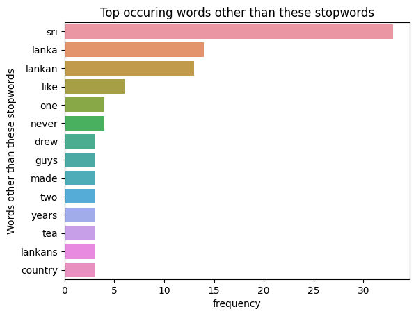

```python
plot_top_non_stopwords_barchart(df2['POST_TITLE'])
plt.title('Top occuring words other than these stopwords')
plt.xlabel('frequency')
plt.ylabel('Words other than these stopwords')
```

## **Ngram exploration**

Ngrams are simply contiguous sequences of n words. For example “riverbank”,” The three musketeers” etc.If the number of words is two, it is called bigram. For 3 words it is called a trigram and so on.

Looking at most frequent n-grams can give you a better understanding of the context in which the word was used.

```python
# Code Snippet for Top N-grams Barchart

import seaborn as sns
import numpy as np
from nltk.corpus import stopwords
from sklearn.feature_extraction.text import CountVectorizer
from collections import  Counter

def plot_top_ngrams_barchart(text, n=2):
    stop=set(stopwords.words('english'))

    new= text.str.split()
    new=new.values.tolist()
    corpus=[word for i in new for word in i]

    def _get_top_ngram(corpus, n=None):
        vec = CountVectorizer(ngram_range=(n, n)).fit(corpus)
        bag_of_words = vec.transform(corpus)
        sum_words = bag_of_words.sum(axis=0)
        words_freq = [(word, sum_words[0, idx])
                      for word, idx in vec.vocabulary_.items()]
        words_freq =sorted(words_freq, key = lambda x: x[1], reverse=True)
        return words_freq[:10]

    top_n_bigrams=_get_top_ngram(text,n)[:15]
    x,y=map(list,zip(*top_n_bigrams))
    sns.barplot(x=y,y=x)
```

### **Top Occuring Bigram**

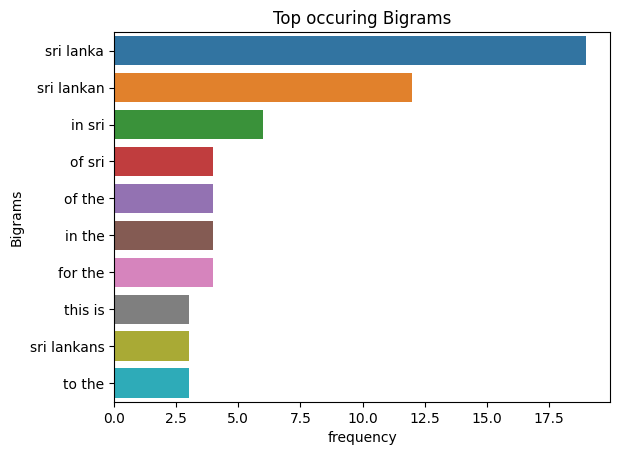

```python
plot_top_ngrams_barchart(df2['POST_TITLE'],2)
plt.title('Top occuring Bigrams')
plt.xlabel('frequency')
plt.ylabel('Bigrams')
```

### **Top Occuring Trigram**

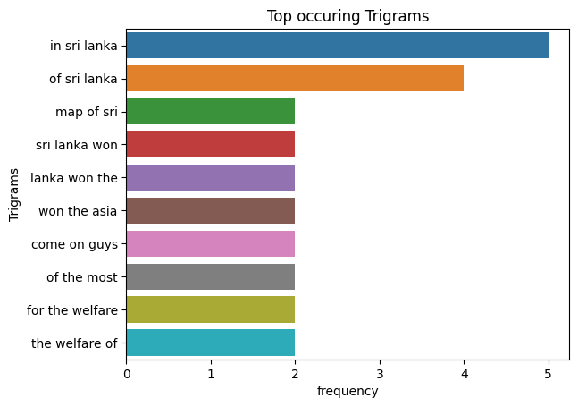

```python
plot_top_ngrams_barchart(df2['POST_TITLE'],3)
plt.title('Top occuring Trigrams')
plt.xlabel('frequency')
plt.ylabel('Trigrams')
```

### **Top Occuring Tetragram**

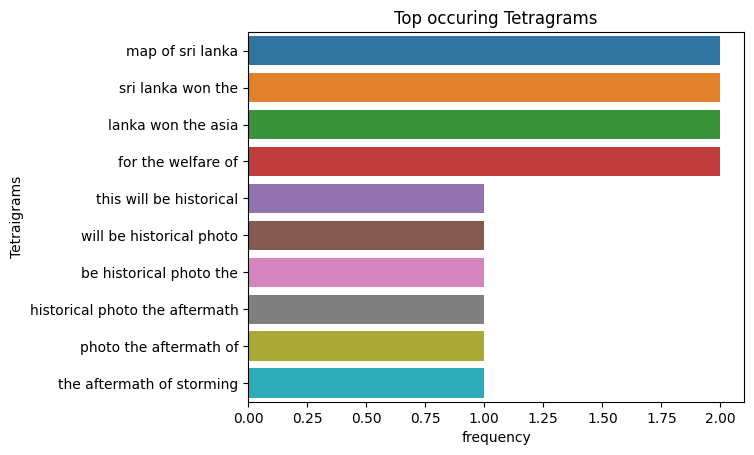

```python
plot_top_ngrams_barchart(df2['POST_TITLE'],4)
plt.title('Top occuring Tetragrams')
plt.xlabel('frequency')
plt.ylabel('Tetraigrams')
```

# **Wordcloud**

```python
import matplotlib.pyplot as plt
import numpy as np
from nltk.corpus import stopwords
from nltk.stem import WordNetLemmatizer,PorterStemmer
from nltk.tokenize import word_tokenize
from wordcloud import WordCloud, STOPWORDS
import nltk
nltk.download('punkt')
nltk.download('wordnet')

def plot_wordcloud(text):
    nltk.download('stopwords')
    stop=set(stopwords.words('english'))

    def _preprocess_text(text):
        corpus=[]
        stem=PorterStemmer()
        lem=WordNetLemmatizer()
        for news in text:
            words=[w for w in word_tokenize(news) if (w not in stop)]

            words=[lem.lemmatize(w) for w in words if len(w)>2]

            corpus.append(words)
        return corpus

    corpus=_preprocess_text(text)

    wordcloud = WordCloud(
        background_color='black',
        stopwords=set(STOPWORDS),
        max_words=100,
        max_font_size=30,
        scale=3,
        random_state=1)

    wordcloud=wordcloud.generate(str(corpus))

    fig = plt.figure(1, figsize=(12, 12))
    plt.axis('off')

    plt.imshow(wordcloud)
    plt.show()
```

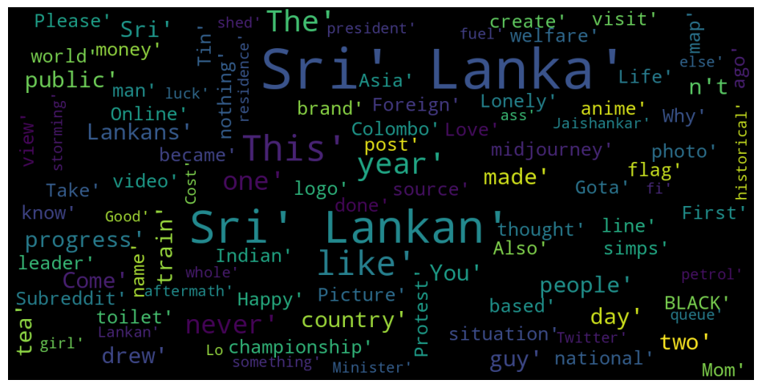

```python
plot_wordcloud(df2['POST_TITLE'])
```